# Lista 5 - Diagnóstico em distribuições - geradores de números uniformes

#### Sejam as funções implementadas em aula para o método congruencial (`congruencial(n, m, a, c, U0)` e `gna0(n, 0)`):

```r
congruencial = function(n, m, a, c, U0) {
  U = c()
  Ui = U0
  for (i in 1:n) {
    Ui = (a * Ui + c) %% m
    U[i] = Ui / m
    # para resultados entre 0 e 1
  }
  return(U)
}
```

```r
gna0 = function(n, sem=0){
  gnu0 = function(sem){ # função local
    k = sem %/% iq # divisao de inteiros
    # calculando (ia * sem mod im) sem provocar overflow - Schrage
    sem = ia * (sem %% iq) - ir * k
    if (sem < 0) sem = sem + im
    ran0 = am * sem # converte sem para ponto flutuante
    return(list(ran0 = ran0, sem = sem))
  }
  ia = 16807; im = 2147483647; am = 1.0 / im
  iq = 127773; ir = 2836
  if(sem <= 0){
    t = as.numeric(substring(Sys.time(),
                             c(1,6,9,12,15,18),c(4,7,10,13,16,19))) # relógio/sist.
    sem = t[6] + t[5] * 60 + t[4] * 3600
    # retirar o efeito inicial
    sem = ia * (sem %% iq) - ir * (sem %/% iq)
    if(sem <= 0) sem = sem + im
  }
  u = matrix(0, n, 1) # inicia o vetor de resultados
  amostra = gnu0(sem) # chama gnu0
  u[1] = amostra$ran0 # inicia o primeiro elemento
  for (i in 2:n){
    amostra = gnu0(amostra$sem)
    u[i] = amostra$ran0
  }
  return(u)
}
```

#### 1. Gere $100$ números uniformes usando a função congruencial com os valores $m = 2147483647$, $a = 16807$, $c = 0$ e sem deve capturar a hora do sistema (como feito na função `gna0`).

```r
n = 100; m = 2147483647; a = 16807; c = 0

t = as.numeric(substring(Sys.time(), c(1,6,9,12,15,18),c(4,7,10,13,16,19))) # relógio/sist.
U0 = t[6] + t[5] * 60 + t[4] * 3600

head(congruencial(n,m,a,c,U0))
```

```
## [1] 0.6405492 0.7102706 0.5175951 0.2200473 0.3345460 0.7146050
```

```r
# ou

congruencial = function(n, m, a, c) {
  U = c()
  t = as.numeric(substring(Sys.time(), c(1,6,9,12,15,18),c(4,7,10,13,16,19))) # relógio/sist.
  U0 = t[6] + t[5] * 60 + t[4] * 3600
  Ui = U0
  for (i in 1:n) {
    Ui = (a * Ui + c) %% m
    U[i] = Ui / m
    # para resultados entre 0 e 1
  }
  return(U)
}

x = congruencial(n,m,a,c)
head(x)
```

```
## [1] 0.6405492 0.7102706 0.5175951 0.2200473 0.3345460 0.7146050
```

A cada vez que executada a função ira obter uma “hora do sistema” diferente e sempre irá gerar um conjunto de numeros aleatorios diferente.

#### 2. Gere $100$ números uniformes usando a função `gna0`, com a semente 0 (que faz com que a hora do sistema seja utilizada).

```r
n = 100
u = gna0(n,0)
head(u)
```

```
##           [,1]
## [1,] 0.7102706
## [2,] 0.5175951
## [3,] 0.2200473
## [4,] 0.3345460
## [5,] 0.7146050
## [6,] 0.3666141
```

#### 3. Avalie as amostras geradas pelas duas funções (a e b) de acordo com a função distribuição empírica da $U(0, 1)$ e comente no próprio script os resultados obtidos. Use os comandos:

`plot(sort(x), 1:length(x)/length(x))`  
`abline(0, 1)`

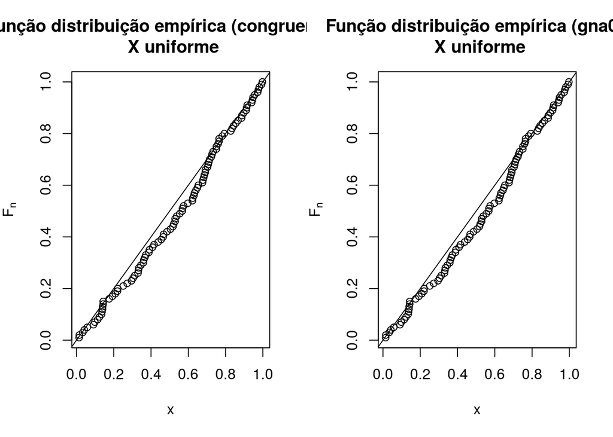

```r
par(mfrow = c(1,2))
plot(sort(x), 1:length(x)/length(x),
     xlab = "x", ylab = expression(F[n]),
     main = "Função distribuição empírica (congruencial) \n X uniforme")
abline(0, 1)

plot(sort(u), 1:length(u)/length(u),
     xlab = "x", ylab = expression(F[n]),
     main = "Função distribuição empírica (gna0) \n X uniforme")
abline(0, 1)
```

```r
# Ambas as amostras, tando a gerada pela função congruencial quanto a gerada pela função gna0, seguem uma distribuição uniforme U(0,1).
```

#### 4. Avalie as amostras geradas pelas duas funções de acordo com a função distribuição empírica da $U(0, 1)$ usando o gráfico gerado a partir do comando `ecdf`. Comente.

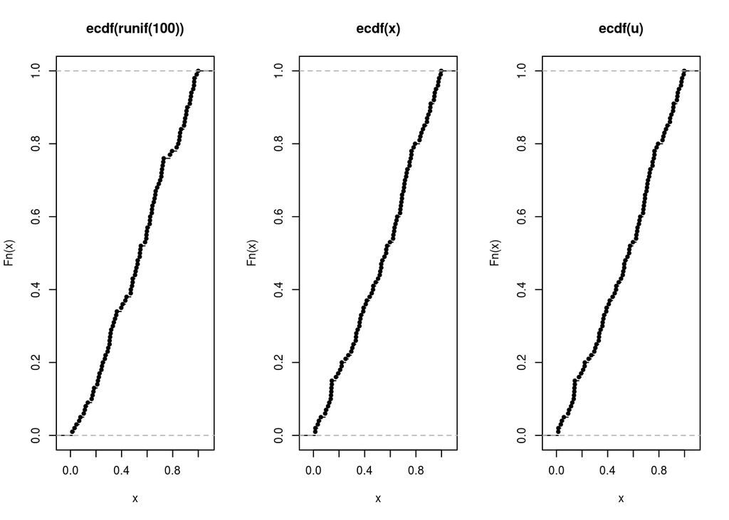

```r
par(mfrow = c(1,3))
plot(ecdf(runif(100)))
plot(ecdf(x))
plot(ecdf(u))
```

#### 5. Obtenha os histogramas (com a estimação kernel) das duas amostras geradas. Comente.

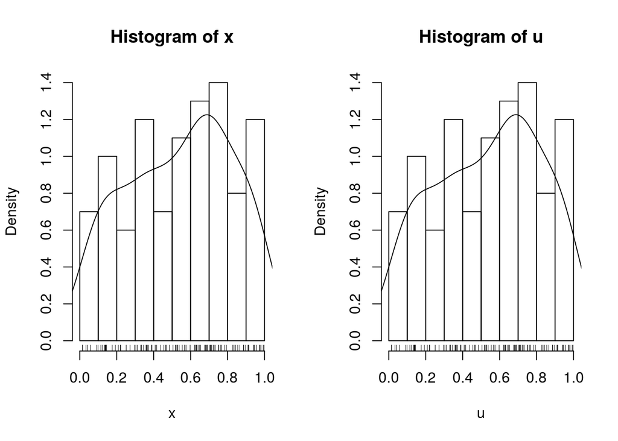

```r
par(mfrow = c(1,2))
hist(x, probability = T)
rug(x) # adiciona dados originais ao histograma
lines(density(x)) # estimação kernel

hist(u, probability = T)
rug(u) # adiciona dados originais ao histograma
lines(density(u)) # estimação kernel
```

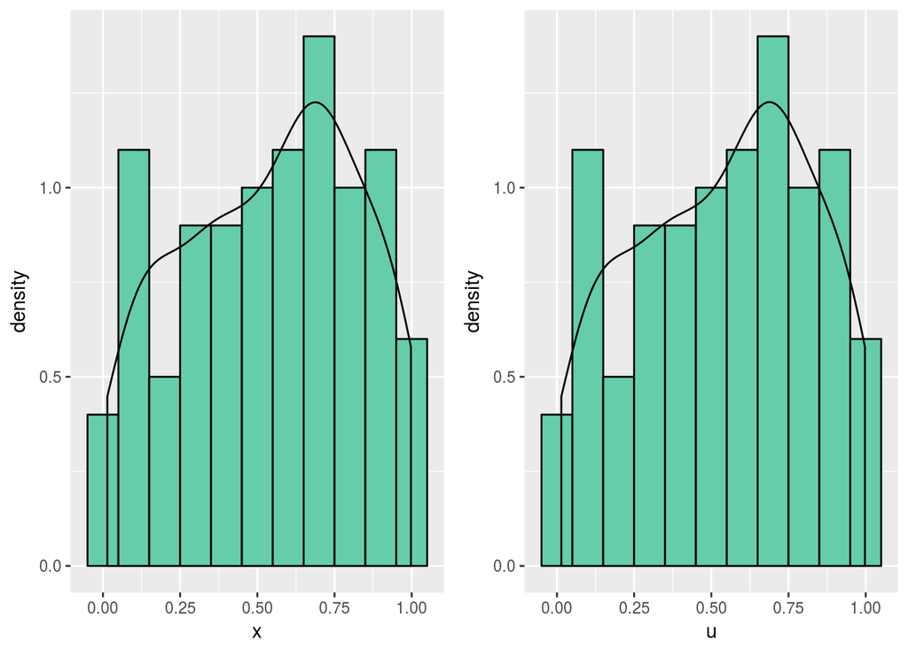

```r
# Com o ggplot :D

library(grid)
library(ggplot2)
pushViewport(viewport(layout=grid.layout(1, 2)))
a = ggplot(,aes(x)) + geom_histogram(aes(y=..density..),
                                 binwidth = 0.1, colour="black", fill='#66CDAA') +
  geom_density(alpha=.2)

b = ggplot(,aes(u)) + geom_histogram(aes(y=..density..),
                                 binwidth = 0.1, colour="black", fill='#66CDAA') +
  geom_density(alpha=.2)
print(a, vp = viewport(layout.pos.row = 1, layout.pos.col = 1))
print(b, vp = viewport(layout.pos.row = 1, layout.pos.col = 2))
```

#### 6. Utilize o teste de Kolmogorov-Smirnov com α = 0,05$ para verificar se as amostras parecem provir de uma $U(0, 1)$. Interprete.

```r
ks.test(x, "punif", 0, 1)
```

```
##
##  One-sample Kolmogorov-Smirnov test
##
## data:  x
## D = 0.091844, p-value = 0.3678
## alternative hypothesis: two-sided
```

```r
ks.test(u, "punif", 0, 1)
```

```
##
##  One-sample Kolmogorov-Smirnov test
##
## data:  u
## D = 0.091844, p-value = 0.3678
## alternative hypothesis: two-sided
```

#### 7. Utilize o teste $\chi^{2}$ com $α = 0,05$ para verificar se as amostras parecem provir de uma $U(0, 1)$. Use as contagens das classes dos histogramas obtidos no R.

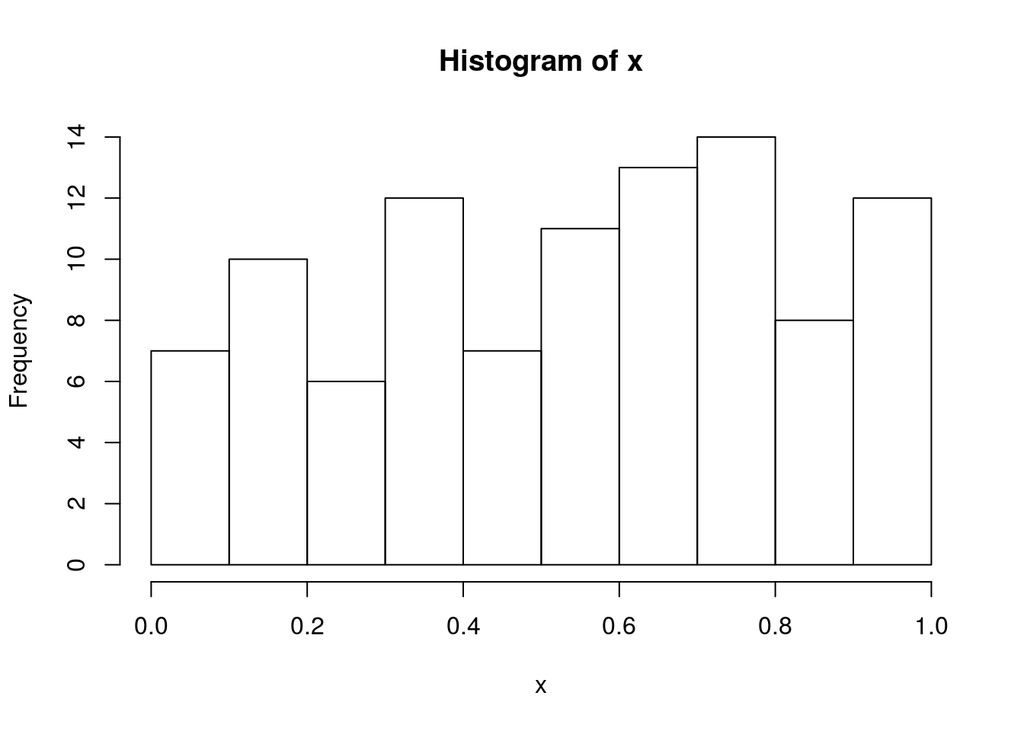

```r
h = hist(x)
```

```r
h$counts
```

```
##  [1]  7 10  6 12  7 11 13 14  8 12
```

```r
chisq.test(h$counts)
```

```
##
##  Chi-squared test for given probabilities
##
## data:  h$counts
## X-squared = 7.2, df = 9, p-value = 0.6163
```

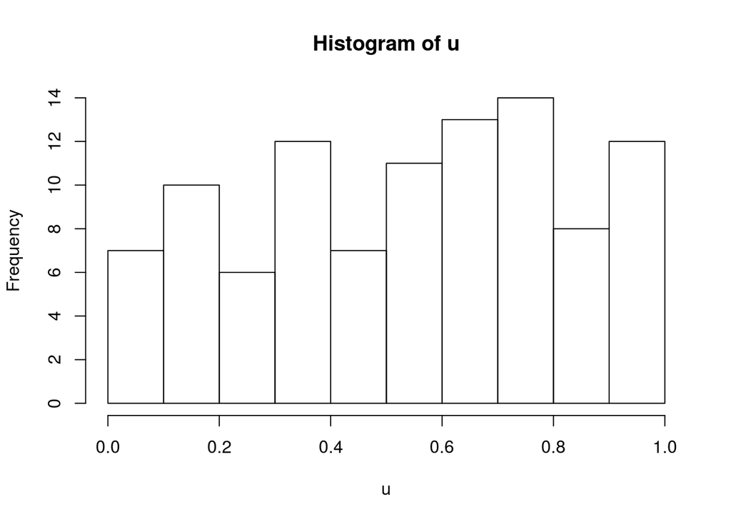

```r
h = hist(u)
```

```r
h$counts
```

```
##  [1]  7 10  6 12  7 11 13 14  8 12
```

```r
chisq.test(h$counts)
```

```
##
##  Chi-squared test for given probabilities
##
## data:  h$counts
## X-squared = 7.2, df = 9, p-value = 0.6163
```